# Loan Features Effect on Loan Status and Borrower's APR

## Preliminary Wrangling

> This data set contains 113,937 loans with 81 variables on each loan, including loan amount, borrower rate (or interest rate), current loan status, borrower income, and many others.

```python
# Import all packages and set plots to be embedded inline
import numpy as np
import pandas as pd
import matplotlib.pyplot as plt
import seaborn as sb

%matplotlib inline

# Ignore warning messages
import warnings
warnings.filterwarnings('ignore')
```

```python
# Load in the dataset into a pandas dataframe & print statistics
df=pd.read_csv('prosperLoanData.csv')
df.head(10)
```

|  | ListingKey | ListingNumber | ListingCreationDate | CreditGrade | Term | LoanStatus | ClosedDate | BorrowerAPR | BorrowerRate | LenderYield | ... | LP_ServiceFees | LP_CollectionFees | LP_GrossPrincipalLoss | LP_NetPrincipalLoss | LP_NonPrincipalRecoverypayments | PercentFunded | Recommendations | InvestmentFromFriendsCount | InvestmentFromFriendsAmount | Investors |
| --- | --- | --- | --- | --- | --- | --- | --- | --- | --- | --- | --- | --- | --- | --- | --- | --- | --- | --- | --- | --- | --- |
| 0 | 1021339766868145413AB3B | 193129 | 2007-08-26 19:09:29.263000000 | C | 36 | Completed | 2009-08-14 00:00:00 | 0.16516 | 0.1580 | 0.1380 | ... | -133.18 | 0.0 | 0.0 | 0.0 | 0.0 | 1.0 | 0 | 0 | 0.0 | 258 |
| 1 | 10273602499503308B223C1 | 1209647 | 2014-02-27 08:28:07.900000000 | NaN | 36 | Current | NaN | 0.12016 | 0.0920 | 0.0820 | ... | 0.00 | 0.0 | 0.0 | 0.0 | 0.0 | 1.0 | 0 | 0 | 0.0 | 1 |
| 2 | 0EE9337825851032864889A | 81716 | 2007-01-05 15:00:47.090000000 | HR | 36 | Completed | 2009-12-17 00:00:00 | 0.28269 | 0.2750 | 0.2400 | ... | -24.20 | 0.0 | 0.0 | 0.0 | 0.0 | 1.0 | 0 | 0 | 0.0 | 41 |
| 3 | 0EF5356002482715299901A | 658116 | 2012-10-22 11:02:35.010000000 | NaN | 36 | Current | NaN | 0.12528 | 0.0974 | 0.0874 | ... | -108.01 | 0.0 | 0.0 | 0.0 | 0.0 | 1.0 | 0 | 0 | 0.0 | 158 |
| 4 | 0F023589499656230C5E3E2 | 909464 | 2013-09-14 18:38:39.097000000 | NaN | 36 | Current | NaN | 0.24614 | 0.2085 | 0.1985 | ... | -60.27 | 0.0 | 0.0 | 0.0 | 0.0 | 1.0 | 0 | 0 | 0.0 | 20 |
| 5 | 0F05359734824199381F61D | 1074836 | 2013-12-14 08:26:37.093000000 | NaN | 60 | Current | NaN | 0.15425 | 0.1314 | 0.1214 | ... | -25.33 | 0.0 | 0.0 | 0.0 | 0.0 | 1.0 | 0 | 0 | 0.0 | 1 |
| 6 | 0F0A3576754255009D63151 | 750899 | 2013-04-12 09:52:56.147000000 | NaN | 36 | Current | NaN | 0.31032 | 0.2712 | 0.2612 | ... | -22.95 | 0.0 | 0.0 | 0.0 | 0.0 | 1.0 | 0 | 0 | 0.0 | 1 |
| 7 | 0F1035772717087366F9EA7 | 768193 | 2013-05-05 06:49:27.493000000 | NaN | 36 | Current | NaN | 0.23939 | 0.2019 | 0.1919 | ... | -69.21 | 0.0 | 0.0 | 0.0 | 0.0 | 1.0 | 0 | 0 | 0.0 | 1 |
| 8 | 0F043596202561788EA13D5 | 1023355 | 2013-12-02 10:43:39.117000000 | NaN | 36 | Current | NaN | 0.07620 | 0.0629 | 0.0529 | ... | -16.77 | 0.0 | 0.0 | 0.0 | 0.0 | 1.0 | 0 | 0 | 0.0 | 1 |
| 9 | 0F043596202561788EA13D5 | 1023355 | 2013-12-02 10:43:39.117000000 | NaN | 36 | Current | NaN | 0.07620 | 0.0629 | 0.0529 | ... | -16.77 | 0.0 | 0.0 | 0.0 | 0.0 | 1.0 | 0 | 0 | 0.0 | 1 |

10 rows × 81 columns

```python
# Data set has 81 columns and 113937 rows
print(df.shape)
```

```
(113937, 81)
```

```python
# Define features of interest for this analysis
main_features=['LoanStatus', 'ListingCategory (numeric)', 'EmploymentStatus',
          'CurrentCreditLines', 'OpenRevolvingAccounts', 'DebtToIncomeRatio',
            'IncomeVerifiable', 'LoanOriginalAmount', 'BorrowerAPR',
            'StatedMonthlyIncome', 'Term', 'ProsperRating (Alpha)','ProsperScore']
df_sub=df[main_features]
```

```python
df_sub.describe()
```

|  | ListingCategory (numeric) | CurrentCreditLines | OpenRevolvingAccounts | DebtToIncomeRatio | LoanOriginalAmount | BorrowerAPR | StatedMonthlyIncome | Term | ProsperScore |
| --- | --- | --- | --- | --- | --- | --- | --- | --- | --- |
| count | 113937.000000 | 106333.000000 | 113937.00000 | 105383.000000 | 113937.00000 | 113912.000000 | 1.139370e+05 | 113937.000000 | 84853.000000 |
| mean | 2.774209 | 10.317192 | 6.96979 | 0.275947 | 8337.01385 | 0.218828 | 5.608026e+03 | 40.830248 | 5.950067 |
| std | 3.996797 | 5.457866 | 4.63097 | 0.551759 | 6245.80058 | 0.080364 | 7.478497e+03 | 10.436212 | 2.376501 |
| min | 0.000000 | 0.000000 | 0.00000 | 0.000000 | 1000.00000 | 0.006530 | 0.000000e+00 | 12.000000 | 1.000000 |
| 25% | 1.000000 | 7.000000 | 4.00000 | 0.140000 | 4000.00000 | 0.156290 | 3.200333e+03 | 36.000000 | 4.000000 |
| 50% | 1.000000 | 10.000000 | 6.00000 | 0.220000 | 6500.00000 | 0.209760 | 4.666667e+03 | 36.000000 | 6.000000 |
| 75% | 3.000000 | 13.000000 | 9.00000 | 0.320000 | 12000.00000 | 0.283810 | 6.825000e+03 | 36.000000 | 8.000000 |
| max | 20.000000 | 59.000000 | 51.00000 | 10.010000 | 35000.00000 | 0.512290 | 1.750003e+06 | 60.000000 | 11.000000 |

```python
# Look at the dataset
df_sub.head()
```

|  | LoanStatus | ListingCategory (numeric) | EmploymentStatus | CurrentCreditLines | OpenRevolvingAccounts | DebtToIncomeRatio | IncomeVerifiable | LoanOriginalAmount | BorrowerAPR | StatedMonthlyIncome | Term | ProsperRating (Alpha) | ProsperScore |
| --- | --- | --- | --- | --- | --- | --- | --- | --- | --- | --- | --- | --- | --- |
| 0 | Completed | 0 | Self-employed | 5.0 | 1 | 0.17 | True | 9425 | 0.16516 | 3083.333333 | 36 | NaN | NaN |
| 1 | Current | 2 | Employed | 14.0 | 13 | 0.18 | True | 10000 | 0.12016 | 6125.000000 | 36 | A | 7.0 |
| 2 | Completed | 0 | Not available | NaN | 0 | 0.06 | True | 3001 | 0.28269 | 2083.333333 | 36 | NaN | NaN |
| 3 | Current | 16 | Employed | 5.0 | 7 | 0.15 | True | 10000 | 0.12528 | 2875.000000 | 36 | A | 9.0 |
| 4 | Current | 2 | Employed | 19.0 | 6 | 0.26 | True | 15000 | 0.24614 | 9583.333333 | 36 | D | 4.0 |

```python
df_sub.info()
# 6 columns that has null entries:
#EmploymentStatus/CurrentCreditLines/DebtToIncomeRatio/BorrowerAPR/ProsperRating (Alpha)/ProsperScore
```

```
<class 'pandas.core.frame.DataFrame'>
RangeIndex: 113937 entries, 0 to 113936
Data columns (total 13 columns):
LoanStatus                   113937 non-null object
ListingCategory (numeric)    113937 non-null int64
EmploymentStatus             111682 non-null object
CurrentCreditLines           106333 non-null float64
OpenRevolvingAccounts        113937 non-null int64
DebtToIncomeRatio            105383 non-null float64
IncomeVerifiable             113937 non-null bool
LoanOriginalAmount           113937 non-null int64
BorrowerAPR                  113912 non-null float64
StatedMonthlyIncome          113937 non-null float64
Term                         113937 non-null int64
ProsperRating (Alpha)        84853 non-null object
ProsperScore                 84853 non-null float64
dtypes: bool(1), float64(5), int64(4), object(3)
memory usage: 10.5+ MB
```

```python
#Remove 25 loans with missing borrower APR information
df_sub = df_sub[~df_sub.BorrowerAPR.isna()]
```

```python
print("Different employment status")
print(df_sub['EmploymentStatus'].unique())
```

```
Different employment status
['Self-employed' 'Employed' 'Not available' 'Full-time' 'Other' nan
 'Not employed' 'Part-time' 'Retired']
```

```python
# Fill nan values with 'Not available' in EmploymentStatus - 111682 non-null
df_sub['EmploymentStatus'].fillna(value='Not available', inplace=True)
```

```python
# Decode ListingCategory (numeric) feature
ListingCategoryNew  = {0 : 'Not Available', 1 : 'Debt Consolidation', 2 : 'Home Improvement', 3: 'Business',
             4 : 'Personal Loan', 5 : 'Student Use', 6 : 'Auto', 7 : 'Other', 8 : 'Baby&Adoption',
             9 : 'Boat', 10 : 'Cosmetic Procedure', 11 : 'Engagement Ring', 12 : 'Green Loans',
             13 : 'Household Expenses', 14 : 'Large Purchases', 15 : 'Medical/Dental', 16 : 'Motorcycle',
             17 : 'RV', 18 : 'Taxes', 19 : 'Vacation', 20 : 'Wedding Loans'}

df_sub['ListingCategory'] = df_sub['ListingCategory (numeric)'].map(ListingCategoryNew)
```

```python
df_sub[['ListingCategory (numeric)', 'ListingCategory']].head(10)
```

|  | ListingCategory (numeric) | ListingCategory |
| --- | --- | --- |
| 0 | 0 | Not Available |
| 1 | 2 | Home Improvement |
| 2 | 0 | Not Available |
| 3 | 16 | Motorcycle |
| 4 | 2 | Home Improvement |
| 5 | 1 | Debt Consolidation |
| 6 | 1 | Debt Consolidation |
| 7 | 2 | Home Improvement |
| 8 | 7 | Other |
| 9 | 7 | Other |

### What is the structure of your dataset?

There are 113,937 loans in the dataset with 81 features. Below details of features of interest for this analysis:

1.LoanStatus - The current status of the loan: Cancelled, Chargedoff, Completed, Current, Defaulted, FinalPaymentInProgress, PastDue. The PastDue status will be accompanied by a delinquency bucket.

2.ListingCategory - The category selected during borrower's posting: 0 - Not Available, 1 - Debt Consolidation, 2 - Home Improvement, 3 - Business, 4 - Personal Loan, 5 - Student Use, 6 - Auto, 7- Other, 8 - Baby&Adoption, 9 - Boat, 10 - Cosmetic Procedure, 11 - Engagement Ring, 12 - Green Loans, 13 - Household Expenses, 14 - Large Purchases, 15 - Medical/Dental, 16 - Motorcycle, 17 - RV, 18 - Taxes, 19 - Vacation, 20 - Wedding Loans

3.EmploymentStatus - The employment status of the borrower.

4.CurrentCreditLines - The number of current credit lines.

5.OpenRevolvingAccounts - The number of open revolving accounts.

6.DebtToIncomeRatio - The debt to income ratio of the borrower at the time the data was pulled. This value is null if the debt to income ratio is not available. This value is capped at 10.01.

7.IncomeVerifiable - Income supporting documentation available.

8.LoanOriginalAmount - The origination amount of the loan.

9.BorrowerAPR - The Borrower's Annual Percentage Rate (APR) for the loan.

10.StatedMonthlyIncome - The borrower's monthly income.

11.Term - The length of the loan expressed in months.

12.ProsperRating (Alpha) - The Prosper Rating assigned between AA - HR( only applicable for loans originated after July 2009).

13.ProsperScore - A custom risk score from 1-10 built using historical Prosper data ( only applicable for loans originated after July 2009).

### What is/are the main feature(s) of interest in your dataset?

This analysis will focus on figuring out the features that are best for predicting the loan status and the Borrower's APR.

### What features in the dataset do you think will help support your investigation into your feature(s) of interest?

In order to figure out the features predicting the loan status and the Borrower's APR, we will be analysing the selected 11 other features during this project.

I expect that all 11 features to have an effect on both in particular employment's status to have the strongest effect on loan status as the more stable the borrower's employement status the more likely they will pay back their loan and the more likely the amount of the loan has a negative effect on APR as the higher the loan amount the lower the APR. The remaining features will be explored too but i expect them to have a smaller effect on my two features of interest.

## A)Univariate Exploration

> In this section, we will investigate the distributions of individual variables using bar charts, pie charts and histogrammes. We will stop and take a deeper look if we encouter unusual observations in order to find relationships between variables.

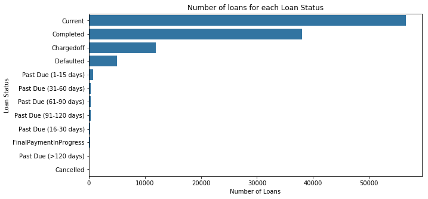

```python
#1.LoanStatus - The current status of the loan
plt.figure(figsize=[10, 5])
sb.countplot(data = df_sub,y = 'LoanStatus',color = sb.color_palette()[0],order=df_sub['LoanStatus'].value_counts().index)
plt.xlabel('Number of Loans')
plt.ylabel('Loan Status')
plt.title('Number of loans for each Loan Status')
plt.show()
# We notice so many subcategories for Past Due so lets group them.
```

```python
# Group all Past Due loans under an unique status
df_sub['LoanStatus'] = df_sub['LoanStatus'].apply(lambda x: x if 'Past Due' not in x else 'Past Due')
```

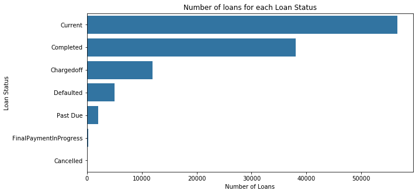

```python
plt.figure(figsize=[10, 5])
sb.countplot(data = df_sub,y = 'LoanStatus', color = sb.color_palette()[0], order=df_sub['LoanStatus'].value_counts().index)
plt.xlabel('Number of Loans')
plt.ylabel('Loan Status')
plt.title('Number of loans for each Loan Status')
plt.show()
```

```python
((df_sub.LoanStatus).value_counts()/float(df_sub.shape[0]))*100
```

```
Current                   49.666409
Completed                 33.402100
Chargedoff                10.527425
Defaulted                  4.405155
Past Due                   1.814559
FinalPaymentInProgress     0.179963
Cancelled                  0.004389
Name: LoanStatus, dtype: float64
```

> Observation 1: We observe that ~83% of the loans are current or completed (94625 out of 113907) and ~15% of the loans are charged-off or defaulted (17010 out of 113907). The remaining 2% represents the Past Due and Final Payment in Progress.

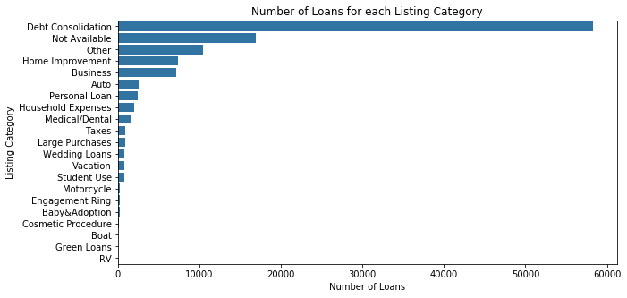

```python
# 2.ListingCategory - The category selected during borrower's posting
plt.figure(figsize=[10, 5])
sb.countplot(data = df_sub, y = 'ListingCategory', color = sb.color_palette()[0], order =df_sub['ListingCategory'].value_counts().index)
plt.ylabel('Listing Category')
plt.xlabel('Number of Loans')
plt.title('Number of Loans for each Listing Category')
plt.show()
```

```python
((df_sub.ListingCategory).value_counts()/float(df_sub.shape[0]))*100
```

```
Debt Consolidation    51.186881
Not Available         14.871129
Other                  9.212374
Home Improvement       6.525212
Business               6.311012
Auto                   2.257883
Personal Loan          2.102500
Household Expenses     1.752230
Medical/Dental         1.336119
Taxes                  0.776916
Large Purchases        0.769015
Wedding Loans          0.676838
Vacation               0.674205
Student Use            0.663670
Motorcycle             0.266873
Engagement Ring        0.190498
Baby&Adoption          0.174696
Cosmetic Procedure     0.079886
Boat                   0.074619
Green Loans            0.051794
RV                     0.045649
Name: ListingCategory, dtype: float64
```

> Observation 2 : We can see that debt consolidation(~51%) is the highest category selected overall.

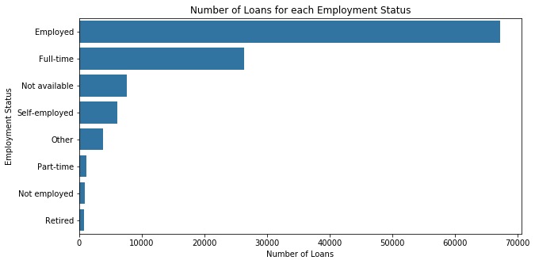

```python
#3.EmploymentStatus - The employment status of the borrower at the time they posted the listing
plt.figure(figsize=[10, 5])
sb.countplot(data = df_sub, y = 'EmploymentStatus',color = sb.color_palette()[0],order=df_sub['EmploymentStatus'].value_counts().index)
plt.ylabel('Employment Status')
plt.xlabel('Number of Loans')
plt.title('Number of Loans for each Employment Status')
plt.show()
```

```python
((df_sub.EmploymentStatus).value_counts()/float(df_sub.shape[0]))*100
```

```
Employed         59.100007
Full-time        23.136281
Not available     6.651626
Self-employed     5.384858
Other             3.341176
Part-time         0.955123
Not employed      0.733022
Retired           0.697907
Name: EmploymentStatus, dtype: float64
```

> Observation 3 : We can see that the majority of the borrowers (~82%) are either employed or full time.

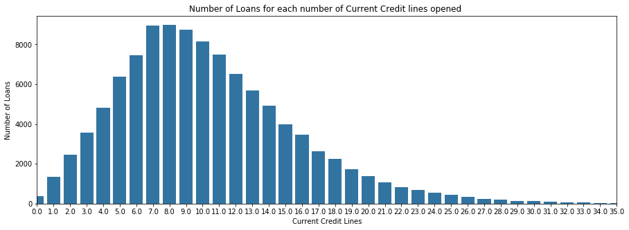

```python
#4.CurrentCreditLines - Number of current credit lines
plt.figure(figsize = [15,5])
sb.countplot(data = df_sub, x = 'CurrentCreditLines', color = sb.color_palette()[0])
plt.xlabel('Current Credit Lines')
plt.ylabel('Number of Loans')
plt.xlim(0,35)
plt.title('Number of Loans for each number of Current Credit lines opened ')
plt.show()
```

> Observation 4: We observe that most borrowers have between 3-18 current credit lines. Similar to the Open Revolving Accounts would be interesting to look at this field in conjuction with the loan status.

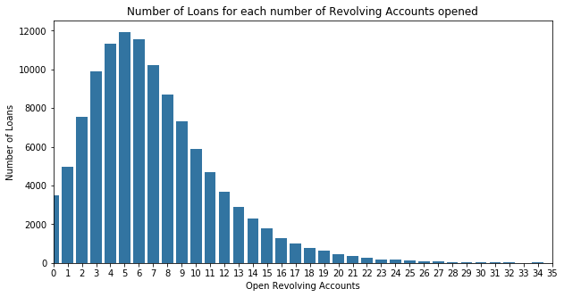

```python
#5.OpenRevolvingAccounts - Number of open revolving accounts
plt.figure(figsize=[10, 5])
sb.countplot(data = df_sub, x = 'OpenRevolvingAccounts', color = sb.color_palette()[0])
plt.xlabel('Open Revolving Accounts')
plt.ylabel('Number of Loans')
plt.title('Number of Loans for each number of Revolving Accounts opened')
plt.xlim(0,35)
plt.show()
```

> Observation 5: We observe that most borrowers have up to 14 revolving accounts. We should analyse all the above 14 cases in conjuction with loan status as i would assume the higher the number of revolving account the less likely the borrower will be able to repay due to his weak financial situation.

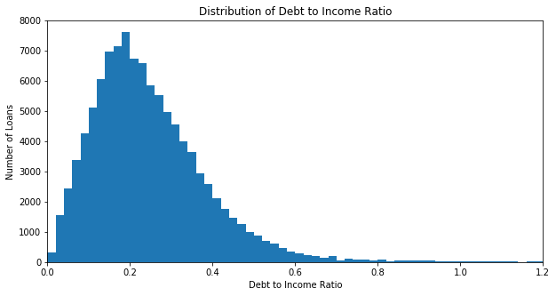

```python
#6.DebtToIncomeRatio - The debt to income ratio of the borrower
plt.figure(figsize=[10, 5])
plt.hist(data = df_sub[df_sub['DebtToIncomeRatio'].notnull()], x = 'DebtToIncomeRatio', bins = np.arange(0, df_sub['DebtToIncomeRatio'].max()+0.02, 0.02))
plt.xlabel('Debt to Income Ratio')
plt.ylabel('Number of Loans')
plt.title('Distribution of Debt to Income Ratio')
plt.xlim(0,1.2)
plt.show();
```

> Observation 6: We can see after zooming in that the distribution is right skewed and the majority of the borrowers have a debt to income ratio between 0 and 0.4.

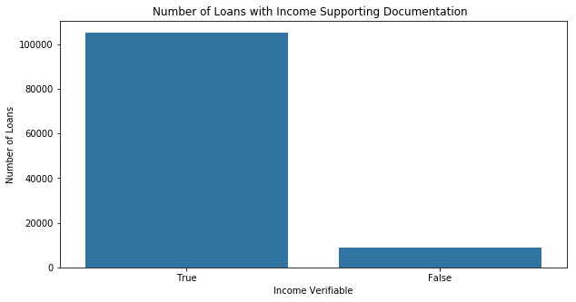

```python
#7.IncomeVerifiable - Income supporting documentation available
plt.figure(figsize=[10, 5])
sb.countplot(data = df_sub, x = 'IncomeVerifiable', color = sb.color_palette()[0], order=df_sub['IncomeVerifiable'].value_counts().index)
plt.xlabel('Income Verifiable')
plt.ylabel('Number of Loans')
plt.title('Number of Loans with Income Supporting Documentation  ')
plt.show()
```

```python
((df_sub.IncomeVerifiable).value_counts()/float(df_sub.shape[0]))*100
```

```
True     92.389739
False     7.610261
Name: IncomeVerifiable, dtype: float64
```

> Observation 7 : We can see that ~92% of the borrowers have income supporting documentation available. I think looking at this feature along employment status would be very interesting.

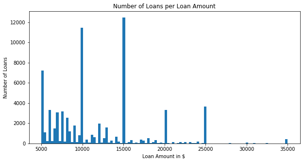

```python
#8.LoanOriginalAmount - The origination amount of the loan
plt.figure(figsize=[10, 5])
plt.hist(data = df_sub, x = 'LoanOriginalAmount', color = sb.color_palette()[0],bins = np.arange(5000, df_sub['LoanOriginalAmount'].max()+300, 300))
plt.xlabel('Loan Amount in $ ')
plt.ylabel('Number of Loans')
plt.title('Number of Loans per Loan Amount')
plt.show()
```

> Observation 8: We observe we have large spiked at 5k,10k,15k,20kand 25k which shows that borrower tend to take mutiple of 5k loan amounts.

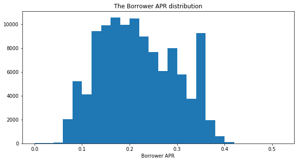

```python
#9.BorrowerAPR - The Borrower's Annual Percentage Rate (APR) for the loan
plt.figure(figsize=[10, 5])
plt.hist(df_sub['BorrowerAPR'], bins = np.arange(0, df_sub['BorrowerAPR'].max()+0.02, 0.02))
plt.xlabel('Borrower APR')
plt.title('The Borrower APR distribution')
plt.show()
```

> Observation 9 : We observe mutiple peaks here at 0.1,0.2,0.3 and ~0.35 with very few loans greater than 0.4 so this distribution seems multimodal.

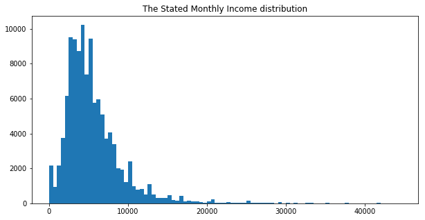

```python
#10.StatedMonthlyIncome - The monthly income the borrower stated
plt.figure(figsize=[10, 5])
plt.hist(data = df_sub, x = 'StatedMonthlyIncome', bins=np.arange(0, 45000, 500), color = sb.color_palette()[0])
plt.title('The Stated Monthly Income distribution')
plt.show()
```

```python
((df_sub.StatedMonthlyIncome>15000).sum()/float(df_sub.shape[0]))*100
```

```
2.4220450874359156
```

> Observation 10: We can see after zooming in that the distribution is right skewed and the majority of the borrowers have a monthly income less than 15k as only ~2.4% have above 15k.

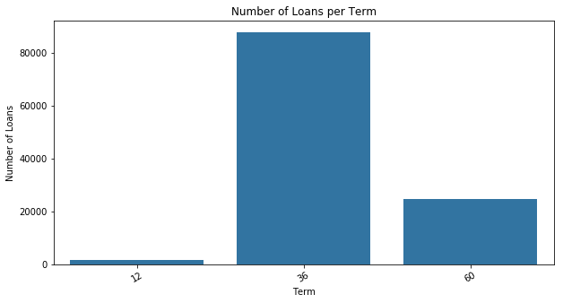

```python
#11.Term - The length of the loan expressed in months
plt.figure(figsize=[10, 5])
sb.countplot(data = df_sub, x = 'Term',color = sb.color_palette()[0])
plt.ylabel('Number of Loans')
plt.xlabel('Term')
plt.xticks(rotation=30)
plt.title('Number of Loans per Term')
plt.show()
```

```python
((df_sub.Term).value_counts()/float(df_sub.shape[0]))*100
```

```
36    77.035782
60    21.547335
12     1.416883
Name: Term, dtype: float64
```

> Observation 11 : We observe that the length of ~77% of the loans is 36 months.

```python
# Convert ProsperRating into ordered categorical types
ProsperRating_order = ['HR','E','D','C','B','A','AA']
ordered_col = pd.api.types.CategoricalDtype(ordered = True,
                                    categories = ProsperRating_order)
df_sub['ProsperRating (Alpha)'] = df_sub['ProsperRating (Alpha)'].astype(ordered_col)
```

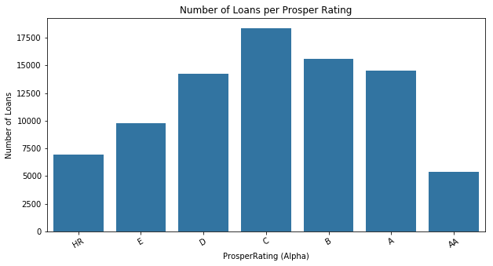

```python
# 12.ProsperRating (Alpha) - The Prosper Rating assigned between AA - HR( only applicable for loans originated after July 2009)
plt.figure(figsize=[10, 5])
sb.countplot(data = df_sub, x = 'ProsperRating (Alpha)', color = sb.color_palette()[0])
plt.ylabel('Number of Loans')
plt.xlabel('ProsperRating (Alpha)')
plt.xticks(rotation=30)
plt.title('Number of Loans per Prosper Rating')
plt.show()
```

```python
((df_sub['ProsperRating (Alpha)']).value_counts()/float(df_sub.shape[0]))*100
```

```
C     16.104537
B     13.678102
A     12.773896
D     12.530725
E      8.598743
HR     6.088033
AA     4.715921
Name: ProsperRating (Alpha), dtype: float64
```

> Observation 12 : We observe that ~56% of borrowers are rated between A-D.

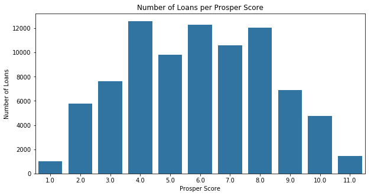

```python
#13.ProsperScore - Custom risk score from 1-10 built using historical Prosper data
plt.figure(figsize=[10, 5])
sb.countplot(data = df_sub, x = 'ProsperScore', color = sb.color_palette()[0])
plt.xlabel('Prosper Score')
plt.ylabel('Number of Loans')
plt.title('Number of Loans per Prosper Score')
plt.show()
```

> Observation 13: We observe that most of the prosper scores are between 2 and 10 points with the highest range is between 4-8.

### Discuss the distribution(s) of your variable(s) of interest. Were there any unusual points? Did you need to perform any transformations?

> In the univariate exploratory analysis, we highlighted that ~50% of the loans are current (56576 out of 113907) and ~15% of the loans are charged-off or defaulted (17010 out of 113907. We noticed also after zooming in that the debt to income ratio distribution is right skewed and the majority of the borrowers have a ratio between 0-0.4.In addition, We saw that ~93% of the borrowers have income supporting documentation available. These observations indicates although half of the loans are current/active, the company has managed to reduce its risk with low debt to income ratio and high available supporting documentation. We also observed that the distribution of borrower's APR is multimodal. We saw mutiple peaks at 0.1,0.2,0.3 and ~0.35 with very few loans greater than 0.4.

### Of the features you investigated, were there any unusual distributions? Did you perform any operations on the data to tidy, adjust, or change the form of the data? If so, why did you do this?

> We decoded Listing Category and then observed in the graph that the highest listing category after debt consolidation are Not available and Other. This observation indicates that the company needs to work on their classification categories to get rid of such uninsightful categories.

> We converted ProsperRating into ordered categorical types so that we can set the order of rating to match the company's raking from lowest to highest.

> In regards Loan Status we have noticed that there are 6 different Past Due categories so we decided to combine them in one category as their total represents only ~1.8%.

## B) Bivariate Exploration

> In this section, we will investigate the relationships between pairs of variables using scatterplots, plot matrix, correlation plot, bar charts,heat maps, violin plots and box plots.

```python
# Group the 7 numerical features
num_vars = ['ProsperScore', 'CurrentCreditLines', 'OpenRevolvingAccounts',
            'DebtToIncomeRatio', 'LoanOriginalAmount','BorrowerAPR',
            'StatedMonthlyIncome']
```

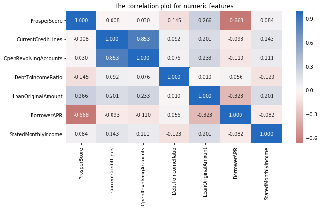

```python
# 1. Correlation plot
plt.figure(figsize = [10, 5])
sb.heatmap(df_sub[num_vars].corr(), annot = True, fmt = '.3f', cmap = 'vlag_r', center = 0)
plt.title('The correlation plot for numeric features')
plt.show()
```

> Observation 1: We observe high positive correlation between CurrentCreditLines & OpenRevolvingAccounts (~0.85) and negative correlation between BorrowerAPR & ProsperScore (-0.67).Similarly between BorrowerAPR & LoanOriginalAmount(-0.32).

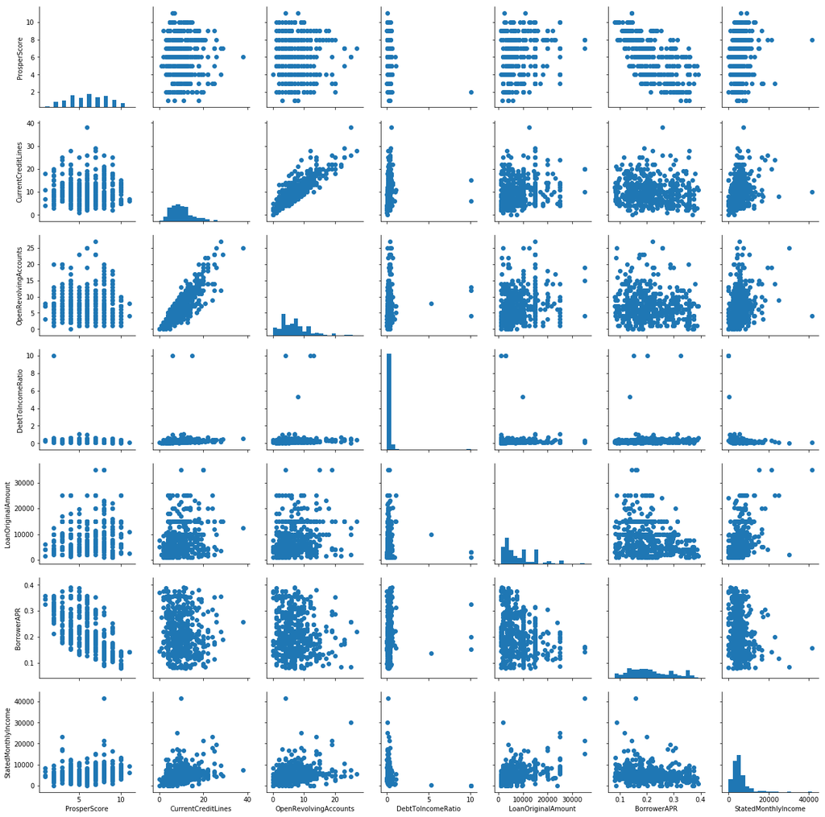

```python
# 2.Plot matrix - sample 500 loans so that plots are clearer and they render faster
samples = np.random.choice(df_sub.shape[0], 500, replace = False)
loan_samples = df_sub.loc[samples,:]
g = sb.PairGrid(data = loan_samples, vars = num_vars)
g = g.map_diag(plt.hist,bins=20)
g.map_offdiag(plt.scatter)
```

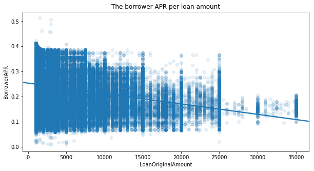

```python
#3. Scatterplot
plt.figure(figsize = [10, 5])
sb.regplot(data = df_sub, x = 'LoanOriginalAmount', y = 'BorrowerAPR', scatter_kws={'alpha':0.1});
plt.title('The borrower APR per loan amount')
```

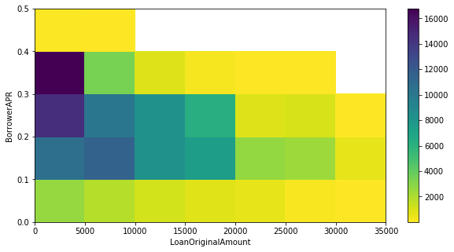

```python
#4.Heat plot
bins_x = np.arange(0, 40000, 5000)
bins_y = np.arange(0, 0.6, 0.1)

plt.figure(figsize=[10, 5])
plt.hist2d(data = df_sub, x = 'LoanOriginalAmount', y = 'BorrowerAPR', cmin=0.5, cmap='viridis_r', bins = [bins_x, bins_y])
plt.colorbar()
plt.xlabel('LoanOriginalAmount')
plt.ylabel('BorrowerAPR');

# Notice the darker areas follow the line from the previous graph and indicates a negative correlation between the two variables too.
#The scatter plot was definitely a better representation of the relationship between the variables then here.
```

> Observation 2: We observe both the positive and negative correlation we highlighted in the previous graph for the plot matrix.Our observation for the scatter plot is also in line with our hypthesis - the higher the loan amount the lower APR.

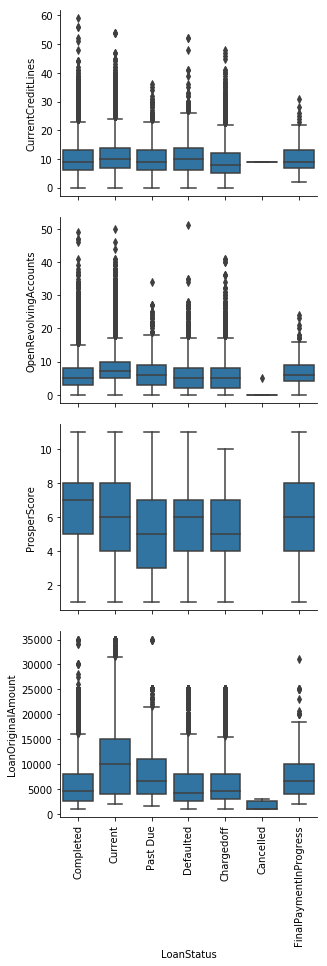

```python
# 5.Box plot & violin plot

def boxgrid(x, y, **kwargs):
    sb.boxplot(x, y, color =sb.color_palette()[0])

plt.figure(figsize = [10, 10])
g = sb.PairGrid(data = df_sub, y_vars = ['CurrentCreditLines', 'OpenRevolvingAccounts','ProsperScore','LoanOriginalAmount'], x_vars = 'LoanStatus',
                size = 3, aspect = 1.5)
g.map(boxgrid)
plt.xticks(rotation=90)
plt.show();
```

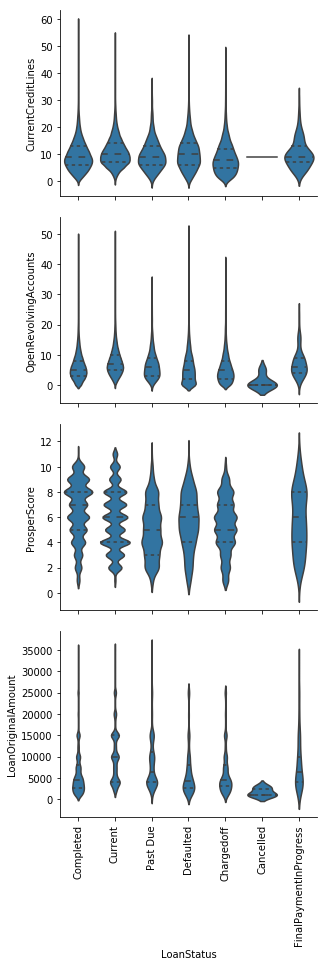

```python
def violingrid(x, y, **kwargs):
    sb.violinplot(x, y, color =sb.color_palette()[0],inner='quartile')

plt.figure(figsize = [10, 10])
g = sb.PairGrid(data = df_sub, y_vars = ['CurrentCreditLines', 'OpenRevolvingAccounts','ProsperScore','LoanOriginalAmount'], x_vars = 'LoanStatus',
                size = 3, aspect = 1.5)
g.map(violingrid)
plt.xticks(rotation=90)
plt.show();
```

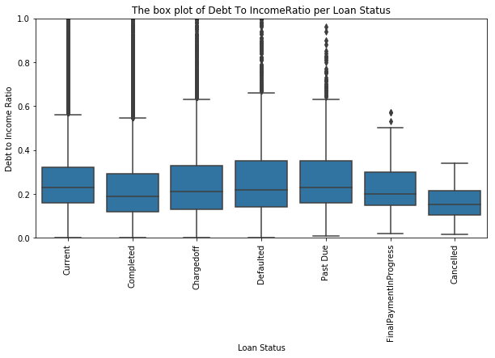

```python
# LoanStatus vs DebtToIncomeRatio
plt.figure(figsize=[10, 5])
ax1 = sb.boxplot(data=df_sub, x='LoanStatus', y='DebtToIncomeRatio', color = sb.color_palette()[0],
                 order=df_sub['LoanStatus'].value_counts().index)
plt.xlabel('Loan Status')
plt.ylabel('Debt to Income Ratio')
plt.xticks(rotation=90)
plt.title('The box plot of Debt To IncomeRatio per Loan Status')
plt.ylim(0,1)

plt.show()
```

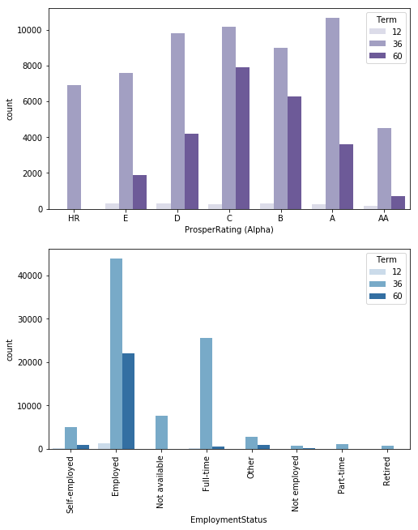

```python
# 6. Bar chart subplots
plt.figure(figsize = [8, 10])

# subplot 1: Prosper rating vs term
plt.subplot(2, 1, 1)
sb.countplot(data = df_sub, x ='ProsperRating (Alpha)', hue ='Term', palette = 'Purples')

# subplot 2: employment status vs. term
ax = plt.subplot(2, 1, 2)
sb.countplot(data =df_sub, x ='EmploymentStatus', hue = 'Term', palette = 'Blues')
plt.xticks(rotation=90)

plt.show()
```

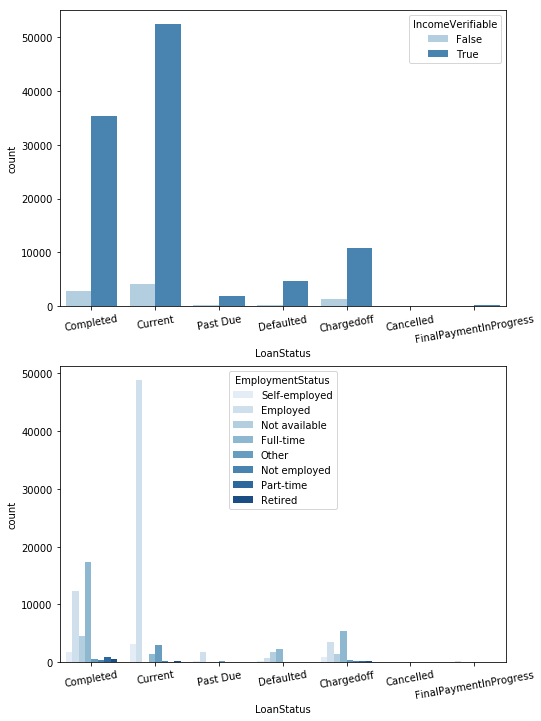

```python
plt.figure(figsize = [8, 12])

# LoanStatus vs IncomeVerifiable
ax = plt.subplot(2, 1, 1)
sb.countplot(data = df_sub, x = 'LoanStatus', hue = 'IncomeVerifiable', palette = 'Blues')
plt.xticks(rotation=10)

#LoanStatus vs EmploymentStatus
ax = plt.subplot(2, 1, 2)
sb.countplot(data = df_sub, x = 'LoanStatus', hue = 'EmploymentStatus',palette = 'Blues')
plt.xticks(rotation=10)

plt.show();
```

> Observation 4: We noticed that employed people take the most number of loans which are all mainly 36 months long with ranking A having the highest 36 months number of loans and ranking C highest 60 months number of loans. There is only 36 months loans for HR rating borrowers.However, we dont have enough data for part-time, retired and not employed borrowers to see any relationship between term and Proper rating for these employment statuses.

> The current loans have a very high income verification which is a good sign as Proper's is ensuring that the borrowers have supporting documentation.

### Talk about some of the relationships you observed in this part of the investigation. How did the feature(s) of interest vary with other features in the dataset?

> In the bivariate exploration we focused on the following 8 features : CurrentCreditLines, OpenRevolvingAccounts, EmplymentStatus, BorrowerAPR, ProsperScore, DebtToIncomeRatio, StatedMonthlyIncome and LoanOriginalAmount.

> We observed high positive correlation between CurrentCreditLines & OpenRevolvingAccounts (~0.85) and negative correlation between BorrowerAPR & ProsperScore (-0.67).Similarly between BorrowerAPR & LoanOriginalAmount(-0.32) - the higher the loan amount the lower APR.

> The Prosper Score of the Past Due and the Charged Off loans have the lowest median which makes sense as we would expect the company to put a bad ranking for these types of loans.

> The current loans have a very high income verification which is a good sign as Proper's is ensuring that the borrowers have supporting documentation.

### Did you observe any interesting relationships between the other features (not the main feature(s) of interest)?

> We noticed a positive relationship between proper score and the original loan amount as higher loans increase the Prosper's risk score.Similarly with loan amount and monthly income as high income borrowers could request higher loan amount.

> There is also a relationship between Prosper's rating and term. We observed that employed people take the most number of loans which are all mainly 36 months long with ranking A having the highest 36 months number of loans and ranking C highest 60 months number of loans. There is only 36 months loans for HR rating borrowers.However, we dont have enough data for part-time, retired and not employed borrowers to see any relationship between term and Proper rating for these employment statuses.

## C) Multivariate Exploration

> In this section, we will investigate the relationships between three or more variables using scatterplots and point plots.

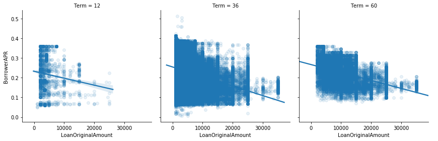

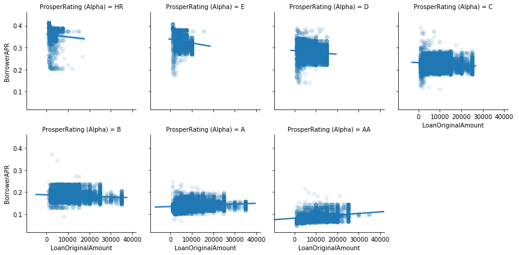

```python
#1.Scatterplot
# Term effect on relationship of APR and loan amount
plt.figure(figsize = [10, 10])
g=sb.FacetGrid(data=df_sub, col='Term', size=4)
g.map(sb.regplot, 'LoanOriginalAmount', 'BorrowerAPR', scatter_kws={'alpha':0.1});
g.add_legend();
# Prosper rating effect on relationship of APR and loan amount
h=sb.FacetGrid(data=df_sub, col='ProsperRating (Alpha)', col_wrap=4)
h.map(sb.regplot, 'LoanOriginalAmount', 'BorrowerAPR', scatter_kws={'alpha':0.1});
h.add_legend();
```

> Observation1: We observe a negative correlation between APR and loan amount regardless of the term. We also notice better Prosper ratings changes the correlation between APR and loan amount from negative to positive. People with higher ratings tend to borrower higher amounts and have lower APR.

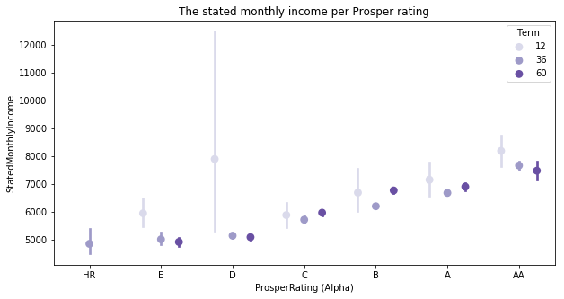

```python
#2.Point plot
plt.figure(figsize=[10, 5])
sb.pointplot(data = df_sub, x = 'ProsperRating (Alpha)', y = 'StatedMonthlyIncome', hue = 'Term',
           palette = 'Purples', linestyles = "", dodge = 0.5)
plt.title('The stated monthly income per Prosper rating')
```

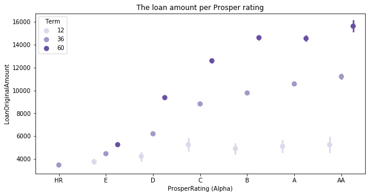

```python
plt.figure(figsize=[10, 5])
sb.pointplot(data = df_sub, x = 'ProsperRating (Alpha)', y = 'LoanOriginalAmount', hue = 'Term',
           palette = 'Purples', linestyles = '', dodge = 0.5)
plt.title('The loan amount per Prosper rating');
```

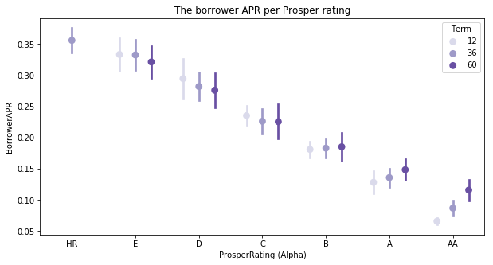

```python
plt.figure(figsize=[10, 5])
sb.pointplot(data = df_sub, x = 'ProsperRating (Alpha)', y = 'BorrowerAPR', hue = 'Term',
           palette = 'Purples', linestyles = '', dodge = 0.5,ci='sd')
plt.title('The borrower APR per Prosper rating')
```

> Observation2: We observe that the borrower APR decrease with the increase of borrow term for borrowers with HR-C raings and the APR increase with the increase of borrow term for borrowers with B-AA ratings.

### Talk about some of the relationships you observed in this part of the investigation. Were there features that strengthened each other in terms of looking at your feature(s) of interest?

> We observed a negative correlation between APR and loan amount regardless of the term. We notice better Prosper ratings changes the correlation between APR and loan amount from negative to positive. People with higher ratings tend to borrower higher amounts and have lower APR.

> We also saw that the borrower APR decrease with the increase of borrow term for borrowers with HR-C ratings and the APR increase with the increase of borrow term for borrowers with B-AA ratings.

### Were there any interesting or surprising interactions between features?

> A surprising interaction is that the borrower APR and term are correlated to the Prosper ratings as we described above. Similarly for the borrower APR and loan amount correlation that changes sign depending on the Prosper ratings.

# Conclusion